# Week 4

September 26, 2024

# Data Exploration 5101

## Dr. Clifton Baldwin and Prof. Melissa Laurino

For food safety reasons, I was asked the question of what temperature is the interior of my refrigerator and does it exceed safety limits during warm weather? I want to make sure my fridge stays below 39°F (or 4°C - recommendations are 5°C but I allow for measurement error)

### Question: Is my Refrigerator Safe According to Food Safety Recommendations

During the summer of 2020, I wired and coded a Raspberry Pi Zero W with two sensors. I mean, the pandemic had many things closed down, and what else was there to do? One sensor detected temperature and relative humidity and the other just temperature (in degrees Celsius). I put the temperature-only sensor in my refrigerator and the dual-sensor outside of my refrigerator. After a week of readings, I downloaded the data file named temperatures.csv from my Raspberry Pi.

# Week 4

In addition to the books we recommend (see the syllabus), you can look at https://www.analyticsvidhya.com/blog/2016/02/complete-tutorial-learn-data-science-scratch/ for more help

Include the libraries we want to use

```r
# If The Tidyverse is not already installed (only have to do this once),
# install.packages('tidyverse', dependencies = TRUE)
# Activate the Tidyverse libraries
library(tidyverse) # includes tibble, readr, dplyr, and several others

# OR
# Alternatively I can load the individual packages
library(tibble)
library(readr)
library(dplyr)
```

Now we have an idea what data we have by using glimpse() and summary(), and we are ready to do some string and date manipulations. stringr is part of the tidyverse package but lubridate needs to be read separately.

```r
library(stringr) # For string manipulations
library(lubridate) # Easier way to work with dates (easier than base R)
```

If lubridate did not load, you may need to install it the first time you want to use it. install.packages(‘lubridate’, dependencies = TRUE)

The Tidyverse package stringr https://stringr.tidyverse.org/ All functions in stringr start with str_ and take a vector of strings as the first argument.

Read in the data, as we did in week 2

```r
# Comment to describe what the code does
# Read the dataset using the readr function read_csv
fridge <- read_csv('temperatures.csv', col_names = TRUE)
```

Now there is a variable, actually a data frame, called fridge that has the contents of temperatures.csv in memory.

```r
glimpse(fridge)
```

```
Rows: 5,588
Columns: 5
$ counter           <chr> "1", "Motion", "2", "3", "4", "5", "6", "7", "8", "9", "10", "11", "12", "1…
$ currentDate       <dttm> 2020-08-24 11:43:44, 2020-08-24 11:44:42, 2020-08-24 11:46:14, 2020-08-24 …
$ external_temp     <dbl> 21, 21, 21, 21, 21, 21, 21, 21, 21, 21, 21, 21, 21, 21, 21, 21, 21, 21, 21,…
$ external_humidity <dbl> 65, 65, 65, 65, 65, 65, 65, 65, 65, 65, 65, 65, 65, 65, 65, 65, 65, 65, 65,…
$ internal_temp     <dbl> 11.3750, 14.4375, 11.7500, 12.6875, 11.6250, 9.3750, 8.3750, 7.8750, 7.4375…
```

## Strings

To count the number of occurrences of “Motion”, we can call str_count()

```r
str_count(fridge$counter, "Motion") %>%
  head(n=20) # pipe it to head so we see only the first 20
```

```
 [1] 0 1 0 0 0 0 0 0 0 0 0 0 0 0 0 0 0 0 0 0
```

That gives us a count for EACH observation, which is not very useful in this case. We can call str_detect() to see if the string “Motion” exists in each observation

```r
str_detect(fridge$counter, "Motion") %>%
  head(n=20)
```

```
 [1] FALSE  TRUE FALSE FALSE FALSE FALSE FALSE FALSE FALSE FALSE FALSE FALSE FALSE FALSE FALSE FALSE
[17] FALSE FALSE FALSE FALSE
```

That tells us if “Motion” exists in each observation, but again not very useful in this case. However, combining str_detect with sum() will give us a total.

```r
sum(str_detect(fridge$counter, "Motion"))
```

```
[1] 69
```

I could have piped the two functions also,

```r
str_detect(fridge$counter, "Motion") %>%
  sum()
```

```
[1] 69
```

So there are 69 occurrences of the word “Motion” in the variable/column “counter” out of 5588 observations (which we know from earlier analysis). By the way, I could have combined str_count with sum() also, which would give us the total count of the word “Motion” including if it occurs more than once in an observation, which it does not. 69

“Motion” requires me to type 6 letters! Maybe I want just an “M” instead of “Motion”. I can replace every occurrence of the word “Motion” with “M”

If I want the change to stick, I have to save it to something. I can overwrite the existing column `fridge$counter <- str_replace(fridge$counter, "Motion", "M")` or I can create a new column,

```r
fridge$counter2 <- str_replace(fridge$counter, "Motion", "M")

head(fridge[,c(1,6)], n=10) # Print it out - just to see
```

| counter | counter2 |
| --- | --- |
| 1 | 1 |
| Motion | M |
| 2 | 2 |
| 3 | 3 |
| 4 | 4 |
| 5 | 5 |
| 6 | 6 |
| 7 | 7 |
| 8 | 8 |
| 9 | 9 |

Ok, let us do something a bit more useful and change the variable/column names. Note: I could read the data in again (just to reset it as a data.frame / tibble. First), but we made only one change - added counter2. What are the column names in the data.frame fridge? I can always query them with names() (or glimpse() or str() or …)

```r
names(fridge)
```

```
[1] "counter"           "currentDate"       "external_temp"     "external_humidity" "internal_temp"
[6] "counter2"
```

We could save the names as a vector, which I will call var_names

```r
var_names <- names(fridge)
```

I do not like the word “external” but prefer to use “outside”

```r
var_names <- str_replace(var_names, 'external', 'outside')
var_names
```

```
[1] "counter"          "currentDate"      "outside_temp"     "outside_humidity" "internal_temp"
[6] "counter2"
```

I do not like that currentDate is camel-case format but the other variables are using underscore format. I need to change the capital D to lowercase d and then insert an underscore. Since everything should be lowercase, it is easy, but only currentDate needs a “_”

```r
# Change everything to lowercase
var_names <- str_to_lower(var_names)
var_names
```

```
[1] "counter"          "currentdate"      "outside_temp"     "outside_humidity" "internal_temp"
[6] "counter2"
```

I can either change the 2nd element or the variable named currentdate

```r
str_sub(var_names[2],8,8) <- '_'
var_names
```

```
[1] "counter"          "current_ate"      "outside_temp"     "outside_humidity" "internal_temp"
[6] "counter2"
```

Whoops! Looks like I need to take “current” and “date” and put the ’_’ in between. Let me reset.

```r
# Redo the previous commands
var_names <- names(fridge)
var_names <- str_replace(var_names, 'external', 'outside')
var_names <- str_to_lower(var_names)

# Split the variable and add the underscore
var_names[2] <- paste(str_sub(var_names[2], 1, 7), "_", str_sub(var_names[2], 8), sep = "")

# Check to see if it worked this time
var_names
```

```
[1] "counter"          "current_date"     "outside_temp"     "outside_humidity" "internal_temp"
[6] "counter2"
```

Too much work! I can use str_replace with the chosen name. Alternately, I could use grep to find currentdate, which is similar to a Linux Bash command.

```r
# Redo the previous commands
var_names <- names(fridge)
var_names <- str_replace(var_names, 'external', 'outside')
var_names <- str_to_lower(var_names)

# Now split the chosen variable
var_names <- str_replace(var_names, "currentdate", "current_date")
var_names
```

```
[1] "counter"          "current_date"     "outside_temp"     "outside_humidity" "internal_temp"
[6] "counter2"
```

Now that I am happy with it, I need to change fridge to have these names. Remember the names have only been changed in the vector var_names!

```r
names(fridge)
```

```
[1] "counter"           "currentDate"       "external_temp"     "external_humidity" "internal_temp"
[6] "counter2"
```

See! Ok, save the changes to fridge. Note, this changes the names in memory but does NOT change the temperatures.csv file. So the next time we read in temperatures.csv, we will be starting from the beginning again.

```r
names(fridge) <- var_names

glimpse(fridge)
```

```
Rows: 5,588
Columns: 6
$ counter          <chr> "1", "Motion", "2", "3", "4", "5", "6", "7", "8", "9", "10", "11", "12", "13…
$ current_date     <dttm> 2020-08-24 11:43:44, 2020-08-24 11:44:42, 2020-08-24 11:46:14, 2020-08-24 1…
$ outside_temp     <dbl> 21, 21, 21, 21, 21, 21, 21, 21, 21, 21, 21, 21, 21, 21, 21, 21, 21, 21, 21, …
$ outside_humidity <dbl> 65, 65, 65, 65, 65, 65, 65, 65, 65, 65, 65, 65, 65, 65, 65, 65, 65, 65, 65, …
$ internal_temp    <dbl> 11.3750, 14.4375, 11.7500, 12.6875, 11.6250, 9.3750, 8.3750, 7.8750, 7.4375,…
$ counter2         <chr> "1", "M", "2", "3", "4", "5", "6", "7", "8", "9", "10", "11", "12", "13", "1…
```

Notice that counter2 is still in the data frame, which is stored in memory for as long as we do not close R or rm() it.

## DateTimes

Let us move on to the datetimes. Figure out the time of each Motion. For dates and times, I prefer the package lubridate. https://lubridate.tidyverse.org/

https://r4ds.had.co.nz/dates-and-times.html

If current_date was a string (i.e. chr), I would need to convert it to a date. read_csv() did a good job identifying it as a datetime, but sometimes R gets confused and dates get read as characters.

```r
fridge <- fridge %>% mutate(current_date = ymd_hms(current_date))
```

mutate() creates a new column based on some formula - in this case converting current_date to the datetime column current_date (yes, I used the same name and so it just overwrites it). current_date was already a datetime, but now we are sure. If current_date was a character string, it is a date now, or we got an error.

Note, the symbol %>% is a function in magrittr (part of the tidyverse package) that allows us to connect commands together into one big command. The function is meant to do the same thing as a pipe in Linux.

current_date is a date, and we can continue. Let us see what are the current_date of observations with “Motion” as the counter. I will save the output as a vector, although I could leave it as a one-column tibble.

```r
doorOpens <- fridge[str_detect(fridge$counter, "Motion"),"current_date"]$current_date
# Vector of dates
doorOpens
```

```
 [1] "2020-08-24 11:44:42 UTC" "2020-08-24 16:53:29 UTC" "2020-08-24 20:47:41 UTC"
 [4] "2020-08-24 22:47:15 UTC" "2020-08-24 23:11:46 UTC" "2020-08-24 23:24:57 UTC"
 [7] "2020-08-24 23:55:45 UTC" "2020-08-25 00:20:45 UTC" "2020-08-25 00:31:46 UTC"
[10] "2020-08-25 00:56:45 UTC" "2020-08-25 01:36:48 UTC" "2020-08-25 11:09:54 UTC"
[13] "2020-08-25 13:50:38 UTC" "2020-08-25 16:15:20 UTC" "2020-08-25 16:22:02 UTC"
[16] "2020-08-25 16:25:02 UTC" "2020-08-25 20:55:42 UTC" "2020-08-25 20:56:46 UTC"
[19] "2020-08-26 01:35:31 UTC" "2020-08-26 11:49:41 UTC" "2020-08-26 16:13:17 UTC"
[22] "2020-08-26 17:55:26 UTC" "2020-08-26 23:45:08 UTC" "2020-08-27 00:59:50 UTC"
[25] "2020-08-27 10:16:48 UTC" "2020-08-27 14:54:59 UTC" "2020-08-27 16:44:21 UTC"
[28] "2020-08-27 19:15:10 UTC" "2020-08-27 22:49:15 UTC" "2020-08-27 22:49:29 UTC"
[31] "2020-08-28 00:13:34 UTC" "2020-08-28 00:48:16 UTC" "2020-08-28 02:22:39 UTC"
[34] "2020-08-28 16:57:24 UTC" "2020-08-28 17:46:29 UTC" "2020-08-28 23:23:23 UTC"
[37] "2020-08-28 23:34:31 UTC" "2020-08-29 00:42:37 UTC" "2020-08-29 01:21:36 UTC"
[40] "2020-08-29 01:28:35 UTC" "2020-08-29 10:12:41 UTC" "2020-08-29 12:44:39 UTC"
[43] "2020-08-29 12:55:03 UTC" "2020-08-29 13:01:24 UTC" "2020-08-29 13:03:08 UTC"
[46] "2020-08-29 19:06:07 UTC" "2020-08-29 22:59:24 UTC" "2020-08-30 03:02:24 UTC"
[49] "2020-08-30 10:26:17 UTC" "2020-08-30 12:53:44 UTC" "2020-08-30 14:28:40 UTC"
[52] "2020-08-30 14:31:43 UTC" "2020-08-30 14:38:31 UTC" "2020-08-30 16:58:30 UTC"
[55] "2020-08-30 19:40:11 UTC" "2020-08-30 21:31:09 UTC" "2020-08-30 22:57:05 UTC"
[58] "2020-08-30 23:31:32 UTC" "2020-08-30 23:36:10 UTC" "2020-08-31 01:38:34 UTC"
[61] "2020-08-31 11:31:36 UTC" "2020-08-31 11:39:14 UTC" "2020-08-31 13:08:34 UTC"
[64] "2020-08-31 17:21:10 UTC" "2020-08-31 17:22:39 UTC" "2020-08-31 22:20:40 UTC"
[67] "2020-08-31 22:34:39 UTC" "2020-09-01 00:54:43 UTC" "2020-09-01 10:23:52 UTC"
```

doorOpens is now the vector of datetimes where counter == “Motion”

If I want to see what day of the week each observation took place

```r
fridge %>% mutate(day = wday(current_date, label = TRUE)) %>%
  select(counter, day) # select() grabs only the stated columns for output - so I do not see everything
```

| counter | day |
| --- | --- |
| 1 | Mon |
| Motion | Mon |
| 2 | Mon |
| 3 | Mon |
| 4 | Mon |
| 5 | Mon |
| 6 | Mon |
| 7 | Mon |
| 8 | Mon |
| 9 | Mon |

[output cut: 990 more lines]

Using the same code and piping it to count() will tell us how many observations of “Motion” there were per day of the week.

```r
fridge[str_detect(fridge$counter, "Motion"),"current_date"] %>% # Select only observations with "Motion"
  mutate(day = wday(current_date, label = TRUE)) %>%  # determine the day of the week from the date
  count(day) # count observations by day of the week
```

| day | n |
| --- | --- |
| Sun | 12 |
| Mon | 15 |
| Tue | 13 |
| Wed | 5 |
| Thu | 7 |
| Fri | 7 |
| Sat | 10 |

Every day of the week. A problem with the results is the data stretched more than one week. If I really want to know how many times “Motion” occurred per day (as in date and not just day of the week), I can use date() and then determine the day of the week again

```r
fridge[str_detect(fridge$counter, "Motion"),"current_date"] %>% # Select only observations with "Motion"
  mutate(date = date(current_date)) %>% # determine the date
  count(date) %>%  # count observations by date
  mutate(day = wday(date, label = TRUE)) # determine the day of the week from the date
```

| date | n | day |
| --- | --- | --- |
| 2020-08-24 | 7 | Mon |
| 2020-08-25 | 11 | Tue |
| 2020-08-26 | 5 | Wed |
| 2020-08-27 | 7 | Thu |
| 2020-08-28 | 7 | Fri |
| 2020-08-29 | 10 | Sat |
| 2020-08-30 | 12 | Sun |
| 2020-08-31 | 8 | Mon |
| 2020-09-01 | 2 | Tue |

Now that is interesting. I would expect Saturday and Sunday to have the most events, because my wife was home also those days (I was home everyday since it was during the pandemic). Why is Tuesday August 25 such a popular day for Motion?? Maybe I was bored and snacked several times that day??

Ok, what months were the data collected?

```r
fridge[str_detect(fridge$counter, "Motion"),"current_date"] %>% # Select only observations with "Motion"
  mutate(month = month(current_date, label = TRUE)) %>% # Determine the month
  select(month) %>% # Keep only the months
  distinct() # Show only unique values
```

| month |
| --- |
| Aug |
| Sep |

```r
NA
```

Started in August and ended in September. Because I used a lubridate function, R “knows” Aug and Sep are months.

We created a vector of the dates for “Motion” and so let us use that to save some typing code. What was the interval? I can have R figure out the first and last dates and count how many days in between using subtraction.

```r
max(doorOpens) - min(doorOpens)
```

```
Time difference of 7.94387 days
```

How many days and hours is that?

```r
(min(doorOpens) %--% max(doorOpens)) %/% days(1) # Convert to just days
```

```
[1] 7
```

```r
(min(doorOpens) %--% max(doorOpens)) %/% hours(1) # Convert to just hours
```

```
[1] 190
```

7 days or 190 hours, which is almost 8 days since 8 days is 192 hours.

Now we have a good handle on what was collected in the temperatures.csv file and how to work with the contents. Let us do an early exploration of the data now.

```r
summary(fridge)
```

```
   counter           current_date                     outside_temp   outside_humidity
 Length:5588        Min.   :2020-08-24 11:43:44.28   Min.   :19.00   Min.   :61.00
 Class :character   1st Qu.:2020-08-26 11:44:59.59   1st Qu.:20.00   1st Qu.:64.00
 Mode  :character   Median :2020-08-28 11:42:29.75   Median :21.00   Median :65.00
                    Mean   :2020-08-28 11:36:08.50   Mean   :20.85   Mean   :65.24
                    3rd Qu.:2020-08-30 11:36:17.39   3rd Qu.:21.00   3rd Qu.:66.00
                    Max.   :2020-09-01 11:18:21.89   Max.   :24.00   Max.   :72.00
                                                     NA's   :3       NA's   :3
 internal_temp       counter2
 Min.   :-3.8750   Length:5588
 1st Qu.: 0.0625   Class :character
 Median : 2.8750   Mode  :character
 Mean   : 2.4161
 3rd Qu.: 4.3750
 Max.   :18.7500
```

```r
fridge %>%
  filter(internal_temp > 5) %>%
  filter(!str_detect(counter, "Motion") )
```

| counter | current_date | outside_temp | outside_humidity | internal_temp | counter2 |
| --- | --- | --- | --- | --- | --- |
| 1 | 2020-08-24 11:43:44 | 21 | 65 | 11.3750 | 1 |
| 2 | 2020-08-24 11:46:14 | 21 | 65 | 11.7500 | 2 |
| 3 | 2020-08-24 11:48:23 | 21 | 65 | 12.6875 | 3 |
| 4 | 2020-08-24 11:50:26 | 21 | 65 | 11.6250 | 4 |
| 5 | 2020-08-24 11:52:29 | 21 | 65 | 9.3750 | 5 |
| 6 | 2020-08-24 11:54:30 | 21 | 65 | 8.3750 | 6 |
| 7 | 2020-08-24 11:56:34 | 21 | 65 | 7.8750 | 7 |
| 8 | 2020-08-24 11:58:35 | 21 | 65 | 7.4375 | 8 |
| 9 | 2020-08-24 12:00:38 | 21 | 65 | 7.1250 | 9 |
| 10 | 2020-08-24 12:02:39 | 21 | 65 | 6.8750 | 10 |

[output cut: 775 more lines]

```r
fridge %>%
  filter(internal_temp > 5) %>%
  filter(!str_detect(counter, "Motion") ) %>%
  nrow()
```

```
[1] 785
```

That means my refrigerator was too warm from 14.2235912% of the time!

It might be better to visualize it.

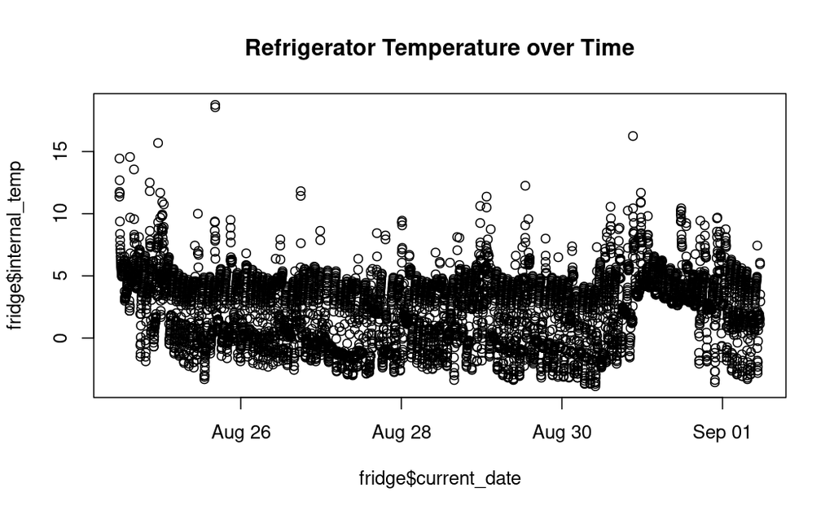

```r
plot(fridge$current_date, fridge$internal_temp, main = "Refrigerator Temperature over Time" )
```

If I want to clean out my environment, I can delete the two vectors I no longer need.

```r
rm(doorOpens, var_names)
```

## Conclusion

For the 7 days of the test (August 24 to September 1, 2020), the external temperature averaged 21°C and the humidity was between 61% and 72%. Although the mean temperature of my refrigerator was 2.4°C, it was out of compliance with food safety standards 14% of the time.

Note that I could conclude something about the temperature on certain days of the week (during the observation period, at least), the relationship between the external and internal temperatures, the relationship with external humidity, and the relationship with opening the refrigerator door (i.e. when “Motion” occurred). Although we found plenty of data during our exploration, our focus is the research question about the temperature range of my refrigerator.

Next we should graph it better to look for patterns. A nice visualization will show the results better than some numbers. Most non-data scientists zone out when you talk numbers and statistics, but a good visualization will get the point across.

# Homework for Week 4

Readings to Compliment This Week’s Topics

```
        i. R for Data Science, chapters 12, 14, 15, 16, https://r4ds.had.co.nz/strings.html
        ii. R Programming for Data Science, ch. 12 & 13
        iii. stringr https://cran.r-project.org/web/packages/stringr/vignettes/stringr.html
        iv. lubridate https://lubridate.tidyverse.org/reference/lubridate-package.html
        v. SQL http://dept.stat.lsa.umich.edu/~jerrick/courses/stat701/notes/sql.html
        vi. https://www.r-bloggers.com/running-sql-queries-in-r-with-the-sqldf-package/
```

**R Mini Project 2**: Due October 10, 2024